# Data import basics

## Import tabular data: MS Excel files

- Using `readxl::read_excel` to read Excel files
- Handles “.xlsx” files effectively

#### Example

**Note**

run `renv::install("readxl")` if needed

```r
library(readxl)
# read Excel file
fp <- file.path("data", "examples", "tabular", "test.xlsx")
df <- read_excel(fp)
glimpse(df)
```

```
Rows: 2
Columns: 2
$ column1 <chr> "a", "b"
$ column2 <dbl> 2, 4
```

## Import non-tabular data

### Overview

- Unstructured and structured non-tabular data
- Handling formats like JSON, XML, HTML

## Import MS Word files (.docx)

- Reading MS Word documents using `officer::read_docx`
- Handling .docx files in data analysis

#### Example

**Note**

run `renv::install("officer")` if needed

```r
library(officer)
# read Word document
fp <- file.path("data", "examples", "files", "test_file.docx")
doc <- read_docx(fp)
content <- docx_summary(doc)
content
```

```
  doc_index content_type      style_name
1         1    paragraph           Title
2         2    paragraph          Author
3         3    paragraph First Paragraph
                                                                                  text
1                                                                            Test file
2                                                                          Hauke Licht
3 This is just a text document for illustrating how to read word and PDF files into R.
  level num_id
1    NA     NA
2    NA     NA
3    NA     NA
```

## Import PDF files (.pdf)

- Extract text from PDF using `pdftools::pdf_text`
- Useful for text processing

#### Example

**Note**

run `renv::install("pdftools")` if needed

```r
library(pdftools)
# extract text from PDF
fp <- file.path("data", "examples", "files", "test_file.pdf")
doc <- pdf_text(fp)
# print first 500 characters in document
cat(substr(doc, 1, 500))
```

```
                                         Test file
                                         Hauke Licht

This is just a text document for illustrating how to read word and PDF files into R.
```

## Import JSON files

- Reading JSON files with `jsonlite::read_json`
- Common in web data and configurations

#### Example

**Note**

run `renv::install("jsonlite")` if needed

```r
library(jsonlite)
# read JSON file
fp <- file.path("data", "examples", "nontabular", "test.json")
data <- read_json(fp)
# show first three elements
data[1:3]
```

```
$null_field
NULL

$logical_field
[1] TRUE

$numeric_field
[1] 1
```

## Import JSONlines files (.jsonl)

- Combining `readr::read_lines`, `purrr::map`, `jsonlite::fromJSON`
- Efficient for large sets of JSON objects

#### Example

```r
library(readr)
library(purrr)
library(jsonlite)
# read JSON lines and convert
fp <- file.path("data", "examples", "nontabular","test.jsonl")
lines <- read_lines(fp)
data <- map(lines, fromJSON)
data
```

```
[[1]]
[[1]]$id
[1] "001"

[[1]]$text
[1] "I'm sorry, I don't understand. Can you try again?"


[[2]]
[[2]]$id
[1] "002"

[[2]]$text
[1] "What is the average length of an elephant's ear?"
```

## Import XML files (.xml)

- `xml2::read_xml` to read XML files
- Widely used in web data, configurations

#### Example

**Note**

run `renv::install("xml2")` if needed

```r
library(xml2)
# read XML file
fp <- file.path("data", "examples", "files", "example.xml")
data <- read_xml(fp)
data
```

```
{xml_document}
<library>
[1] <book id="1">\n  <title>The Great Gatsby</title>\n  <author>F. Scott Fitz ...
[2] <book id="2">\n  <title>To Kill a Mockingbird</title>\n  <author>Harper L ...
[3] <book id="3">\n  <title>1984</title>\n  <author>George Orwell</author>\n  ...
```

## Import HTML files (.html)

- `xml2::read_html` to read HTML content
- Useful for web scraping, data extraction from websites

#### Example

**Note**

run `renv::install("xml2")` if needed

```r
library(xml2)
# read HTML file
fp <- file.path("data", "examples", "files", "example.html")
data <- read_html(fp)
data
```

```
{html_document}
<html lang="en">
[1] <head>\n<meta http-equiv="Content-Type" content="text/html; charset=UTF-8 ...
[2] <body>\n    <h1>Library Catalog</h1>\n    <table>\n<thead><tr>\n<th>ID</t ...
```

# Data import from external sources

Many commonly used political (text) dataset are available online

- [*ParlSpeech2*](https://dataverse.harvard.edu/dataset.xhtml?persistentId=doi:10.7910/DVN/L4OAKN) (Rauh & Schwalbach [2022](https://osf.io/preprints/socarxiv/cd2qs_v1))
- the [*Manifesto Project* dataset](https://manifesto-project.wzb.eu/)
- the *Comparative Agendas Project* ([CAP](https://www.comparativeagendas.net/)) corpora

For replicability and version control purposes, it’s a **best practice** to program the download of these data (instead of manually downloading and saving them)

## Import from *Harvard Dataverse*

Many replication materials for articles published in poltical science journals are available through [**Harvard Dataverse**](https://dataverse.harvard.edu/dataverse/harvard):

Many journals have their own “dataverses”. Here some:

- *American Political Science Review* (APSR): https://dataverse.harvard.edu/dataverse/the_review
- *Political Analysis*: https://dataverse.harvard.edu/dataverse/pan
- *The Journal of Politics* (JOP): https://dataverse.harvard.edu/dataverse/jop
- *Political Science Research & Methods* (PSRM): https://dataverse.harvard.edu/dataverse/PSRM

**IMPORTANT:** In the URLs listed above, the last part behind the last “/” is called “Dataverse ID” – we need this to automatically download files from a journals dataverse

### Example 1: Downloading with the persistent file URL

We will use the replication data of the article

> Bestvater, S., & Monroe, B. (2023). Sentiment is Not Stance: Target-Aware Opinion Classification for Political Text Analysis. *Political Analysis*, 31(2), 235-256.

The repository is https://doi.org/10.7910/DVN/MUYYG4

#### Step 1. locate the file we want to download

1. go to https://doi.org/10.7910/DVN/MUYYG4
2. in the “Files” panel, click “Tree”
3. in the data folder, find and click on the file ‘WM_tweets_groundtruth.tab’
4. on the files page, go to the “Metadata” tab
5. get the value in the field “Download URL”

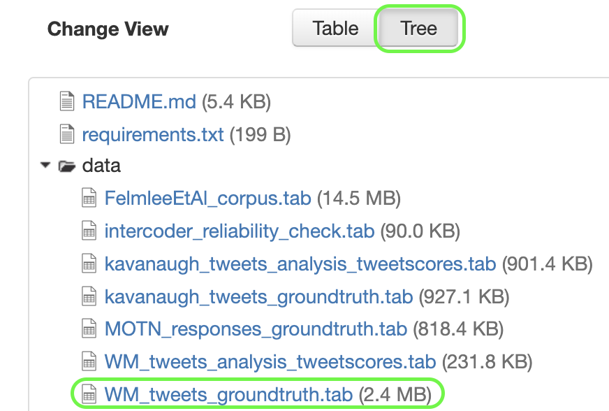

#### Step 2. read the file

```r
file_url <- "https://dataverse.harvard.edu/api/access/datafile/5374866"
# we use `read_tsv` because the file we want to download is a .tab file, i.e. "tab-separated"
df <- read_tsv(file_url)
glimpse(df)
```

[output not shown]

### Example 2: Dowload with file persistent ID

We will use the replication data for the article

> Barberá, P., Boydstun, A. E., Linn, S., McMahon, R., & Nagler, J. (2021). Automated Text Classification of News Articles: A Practical Guide. *Political Analysis*, 29(1), 19–42.

The repository is https://doi.org/10.7910/DVN/MXKRDE

#### Step 1. load the ‘dataverse’ package and set the necessary environment variables

**Note**

run `renv::install("dataverse")` if needed

```r
library(dataverse) # TODO: renv::install("dataverse")
Sys.setenv("DATAVERSE_SERVER" = "dataverse.harvard.edu")
Sys.setenv("DATAVERSE_ID" = "pan") # set to Political Analysis dataverse ID !
```

#### Step 2. locate the file we want to download

1. go to https://doi.org/10.7910/DVN/MXKRDE
2. search for the file ‘ground-truth-dataset-cf.tab’
3. on the files page, go to the “Metadata” tab
4. get the value in the field “File Persistent ID”

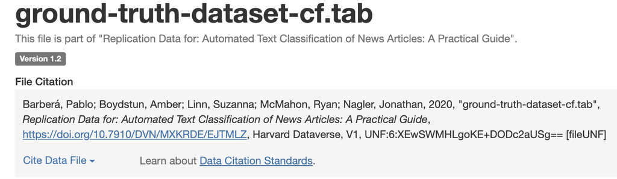

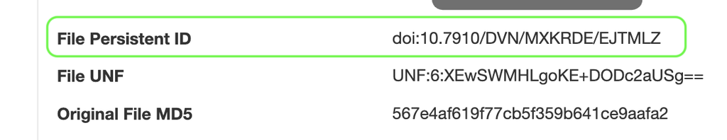

```r
persistent_id <- "doi:10.7910/DVN/MXKRDE/EJTMLZ"
```

#### Step 3. download the file and read it into R

```r
df <- get_dataframe_by_doi(
  # use the file persistent ID to specify which file to download
  filedoi = persistent_id,
  # pass the appropriate file reading function (from the readr package)
  .f = read_tsv,
  # specify concrete file version
  version = "1.2"
)
```

## Download from GitHub

- Github is a code sharing and open-source collaboration platform.
- Some researchers use it to store make available the replication materials

We will use the example of the article

> van Atteveldt, W., van der Velden, M. A. C. G. & Boukes, M. (2021) The Validity of Sentiment Analysis: Comparing Manual Annotation, Crowd-Coding, Dictionary Approaches, and Machine Learning Algorithms. *Communication Methods and Measures*, 15(2), 121-140.

The repository is https://github.com/vanatteveldt/ecosent

#### Step 1. locate the files we want to download

1. go to https://github.com/vanatteveldt/ecosent
2. click on the “data” folder
3. get gold sentences’ texts: in the ‘raw’ subfolder,
   1. find the file ‘gold_sentences.csv’
   2. click on the file
   3. click on the “Raw” button
   4. copy the URL of the raw file
4. get gold sentences’ expert codings: in the intermediate ‘subfolder’
   1. find the file ‘gold.csv’
   2. click on the file
   3. click on the “Raw” button
   4. copy the URL of the raw file

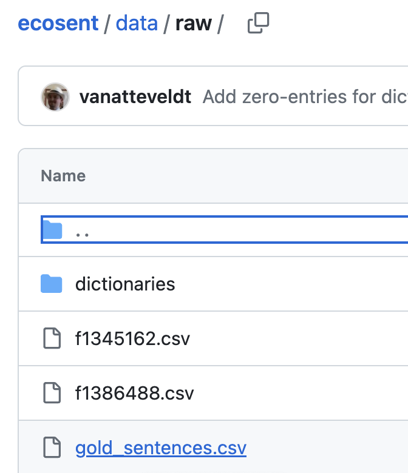

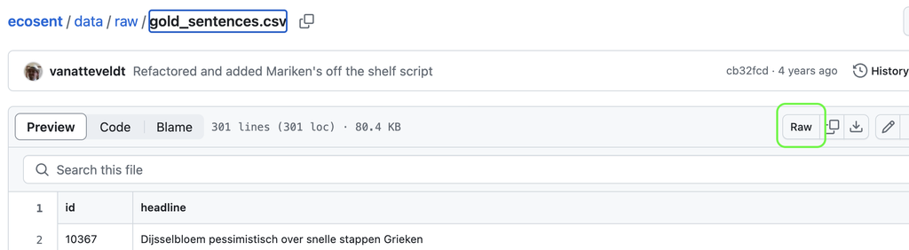

```r
gold_sentences_texts_url <- "https://raw.githubusercontent.com/vanatteveldt/ecosent/master/data/raw/gold_sentences.csv"
gold_sentences_labels_url <- "https://raw.githubusercontent.com/vanatteveldt/ecosent/master/data/intermediate/gold.csv"
```

#### Step 2. download the files and combine them

```r
sentences_df <- read_csv(gold_sentences_texts_url)
labels_df <- read_csv(gold_sentences_labels_url)

colnames(sentences_df)
```

```
[1] "id"            "headline"      "google"        "deepl"
[5] "dutch_lemmas"  "google_lemmas" "deepl_lemmas"
```

```r
colnames(labels_df)
```

```
[1] "id"    "value"
```

*Note:* we use `read_csv` because the file we want to download is a .csv file

```r
library(dplyr)
# compute number of labels per headline
labels_df |>
  group_by(id) |>
  summarise(n_labels = n()) |>
  # count numbers of labels per headlines
  count(n_labels)
```

```
# A tibble: 1 × 2
  n_labels     n
     <int> <int>
1        1   284
```

*Note:* each of 284 headlines has only one label

```r
# combine texts and labels
gold_df <- inner_join(labels_df, sentences_df, by = "id")
```

## Download and extracting from a ZIP file

We can download ZIP archives and extract selected files in R

#### Example

We will use the replication data for the article

> Benoit, K., Conway, D., Lauderdale, B. E., Laver, M., & Mikhaylov, S. (2016). Crowd-sourced Text Analysis: Reproducible and Agile Production of Political Data. *American Political Science Review*, 110(2), 278–295.

The Github repository is here https://github.com/kbenoit/CSTA-APSR

```r
url <- "https://github.com/kbenoit/CSTA-APSR/raw/4bc6cbc48a4eeff557cbb03b8ede73b29e36aa00/Data%20-%20CF%20jobs/CFjobresults.zip"

# download
temp <- tempfile()
download.file(url, temp, quiet = TRUE)

# list contents
conts <- unzip(temp, list = TRUE)$Name
head(conts, 4)
```

```
[1] "f240807.csv" "f246554.csv" "f246609.csv" "f263548.csv"
```

```r
# extract and read selected file
df <- read_csv(unz(temp, "f240807.csv"))

# remove ZIP in temporary location
unlink(temp, recursive = TRUE)

glimpse(df)
```

```
Rows: 2,971
Columns: 28
$ `_unit_id`       <dbl> 323988547, 323988547, 323988547, 323988547, 323988547…
$ `_created_at`    <chr> "9/25/2013 01:29:59", "9/25/2013 11:39:57", "9/26/201…
$ `_golden`        <lgl> FALSE, FALSE, FALSE, FALSE, FALSE, FALSE, FALSE, FALS…
$ `_canary`        <lgl> NA, NA, NA, NA, NA, NA, NA, NA, NA, NA, NA, NA, NA, N…
$ `_id`            <dbl> 1062080778, 1062333755, 1062901797, 1063132332, 10631…
$ `_missed`        <lgl> NA, NA, NA, NA, NA, NA, NA, NA, NA, NA, NA, NA, NA, N…
$ `_started_at`    <chr> "9/25/2013 01:28:34", "9/25/2013 11:38:56", "9/26/201…
$ `_tainted`       <lgl> FALSE, FALSE, FALSE, FALSE, FALSE, FALSE, FALSE, FALS…
$ `_channel`       <chr> "amt", "amt", "amt", "amt", "amt", "amt", "amt", "amt…
$ `_trust`         <dbl> 0.8868, 0.8750, 0.8511, 0.9474, 1.0000, 0.8750, 0.886…
$ `_worker_id`     <dbl> 886, 7918256, 20549618, 5993386, 20749525, 7918256, 8…
$ `_country`       <chr> "USA", "GBR", "USA", "USA", "USA", "GBR", "USA", "USA…
$ `_region`        <chr> "OK", "U3", "NY", "NY", "CO", "U3", "OK", "NY", "NY",…
$ `_city`          <chr> "Tahlequah", "Dundee", "Poughkeepsie", "New York", "D…
$ `_ip`            <chr> "107.200.36.12", "92.233.160.162", "69.121.100.118", …
$ econ_scale       <dbl> 0, NA, 2, -1, 0, -1, NA, -1, 1, 1, -1, 1, -2, -1, 0, …
$ econ_scale2      <lgl> NA, NA, NA, NA, NA, NA, NA, NA, NA, NA, NA, NA, NA, N…
$ policy_area      <dbl> 2, 3, 2, 2, 2, 2, 1, 2, 2, 2, 2, 2, 2, 2, 2, 2, 1, 2,…
$ soc_scale        <dbl> NA, 1, NA, NA, NA, NA, NA, NA, NA, NA, NA, NA, NA, NA…
$ soc_scale2       <lgl> NA, NA, NA, NA, NA, NA, NA, NA, NA, NA, NA, NA, NA, N…
$ orig__golden     <lgl> NA, NA, NA, NA, NA, NA, NA, NA, NA, NA, NA, NA, NA, N…
$ econ_scale_gold  <lgl> NA, NA, NA, NA, NA, NA, NA, NA, NA, NA, NA, NA, NA, N…
$ policy_area_gold <dbl> NA, NA, NA, NA, NA, NA, NA, NA, NA, NA, NA, NA, NA, N…
$ post_sentence    <chr> "The Insolvency Act of 1985 made it easier to disqual…
$ pre_sentence     <chr> "This has brought nearer the day when shares can be b…
$ sentence_text    <chr> "At the same time, the Conservative Government has in…
$ sentenceid       <dbl> 10004831, 10004831, 10004831, 10004831, 10004831, 107…
$ soc_scale_gold   <lgl> NA, NA, NA, NA, NA, NA, NA, NA, NA, NA, NA, NA, NA, N…
```